# DNSC 6301 MKDWN

Katherine Scheuer

8/28/2021

## Load Data from Blackboard

```r
loans = read.csv("C:/Users/yasir/OneDrive/GW/Academic/Analytics Edge and Data Ethics/Project/credit_line_increase.csv")
```

## Cleaning & Prepping Data

##### Create a new version of the data set to base these sets so other code isn’t disturbed

```r
cc <- loans
cc$DELINQ_NEXT <- factor(cc$DELINQ_NEXT,levels=c(0,1), labels=c("No","Yes"))
head(cc)
head(loans)
```

##### Transform demographic into nominal values w better labeling for later

```r
cc$AGE <- cut(cc$AGE,breaks=c(0,20,30,40,50,60,70,80,100), labels=c("<20s","20s", "30s", "40s", "50s", "60s", "70s", "80s+"))
cc$AGE <- factor(cc$AGE)
cc$EDUCATION <- factor(cc$EDUCATION,levels=c(1,2,3,4,5,6), labels=c("Grad School", "University", "High School", "Others", "Unknown", "Unknown"))
cc$PAY_0  <- factor(cc$PAY_0 , levels=c(-2,-1,0,1,2,3,4,5,6,7,8,9), labels=c("Pay duly", "1mo", "2mos", "3mos", "4mos",  "5mos", "6mos", "7mos",  "8mos", "9mos", "10mos", "11mos"))
cc$PAY_2  <- factor(cc$PAY_2 , levels=c(-2,-1,0,1,2,3,4,5,6,7,8,9), labels=c("Pay duly", "1mo", "2mos", "3mos", "4mos",  "5mos", "6mos", "7mos",  "8mos", "9mos", "10mos", "11mos"))
cc$PAY_3  <- factor(cc$PAY_3 , levels=c(-2,-1,0,1,2,3,4,5,6,7,8,9), labels=c("Pay duly", "1mo", "2mos", "3mos", "4mos",  "5mos", "6mos", "7mos",  "8mos", "9mos", "10mos", "11mos"))
cc$SEX <- factor(cc$SEX,levels=c(1,2), labels=c("Male","Female"))
cc$RACE <- factor(cc$RACE,levels=c(1,2,3,4), labels=c("Hispanic","Black", "White", "Asian"))
str(cc)
```

#### Partition the data into training, validation, and test sets

###### Just showing the methodology here.

```r
#Partition the data into training, validation, and test sets
fractionTraining   <- 0.50
fractionValidation <- 0.25
fractionTest       <- 0.25

#Compute sample sizes

sampleSizeTraining   <- floor(fractionTraining   * nrow(cc))
sampleSizeValidation <- floor(fractionValidation * nrow(cc))
sampleSizeTest       <- floor(fractionTest       * nrow(cc))

#check sample sizes
print(sampleSizeTraining)
print(sampleSizeValidation)
print(sampleSizeValidation)

#subsets of indices

indicesTraining    <- sort(sample(seq_len(nrow(cc)), size=sampleSizeTraining))
indicesNotTraining <- setdiff(seq_len(nrow(cc)), indicesTraining)
indicesValidation  <- sort(sample(indicesNotTraining, size=sampleSizeValidation))
indicesTest        <- setdiff(indicesNotTraining, indicesValidation)

#output the three dataframes for training, validation and test
set.seed(12345)
cc_train   <- cc[indicesTraining, ]
cc_validation <- cc[indicesValidation, ]
cc_test       <- cc[indicesTest, ]
```

## Using validation-based early stopping and cross-validation

##### This cross table was also produced in the python set, but it is interesting to see that the same result can be achieved in R. It is clear that the validation and test data are not very well matched, as the actual vs predicted values have large discrepancies. These results lead me to conduct further exploration of the accuracy in the next step.

```r
#cross validation comparing test & validation data
CrossTable(cc_test$DELINQ_NEXT, cc_validation$DELINQ_NEXT,
           prop.chisq = FALSE, prop.c = FALSE, prop.r = FALSE,
           dnn = c('actual default', 'predicted default'))
```

```
##
##
##    Cell Contents
## |-------------------------|
## |                       N |
## |         N / Table Total |
## |-------------------------|
##
##
## Total Observations in Table:  7500
##
##
##                | predicted default
## actual default |        No |       Yes | Row Total |
## ---------------|-----------|-----------|-----------|
##             No |      4507 |      1317 |      5824 |
##                |     0.601 |     0.176 |           |
## ---------------|-----------|-----------|-----------|
##            Yes |      1312 |       364 |      1676 |
##                |     0.175 |     0.049 |           |
## ---------------|-----------|-----------|-----------|
##   Column Total |      5819 |      1681 |      7500 |
## ---------------|-----------|-----------|-----------|
##
##
```

## Use Naive Bayes Method to compare Test & Validation data & calcualte AUC

##### When AUC is approximately 0.5, we know that the model has no discrimination capacity to distinguish between positive class and negative classes. According to the coin flip principle, if AUC is close to .5, we should just flip a coin instead of using model! Using Naive Bayes is helpful as it indicates that we the model & validation set needs to be adjusted in order to improve the AUC & discrimination capacity of the model.

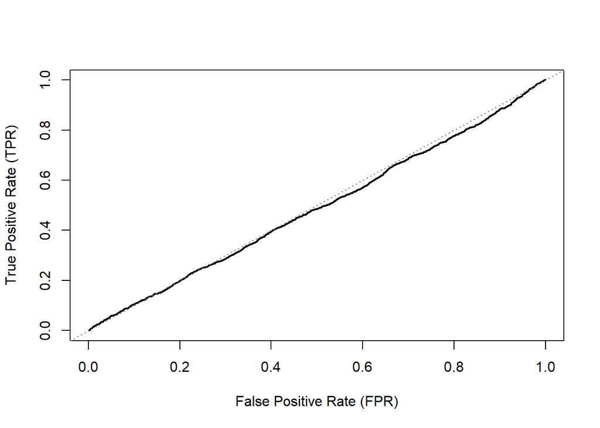

```
## [1] 0.488883
```

##### We see from this chart that the AUC is very close to 50%, so we know that the validation set is not strong. If there was more time in the project, it would be useful to remove different variables & see how the AUC changes.

## Filter Out Financial Data

##### We filter out financial data in order to plot a decision tree without the demographic variables. If there was more time, it would be useful to test the AUC of these new test, training, and validation sets.

```r
#filter data now! (changed from first atttempt)
cc_trainfin <- cc_train %>% select('DELINQ_NEXT', 'LIMIT_BAL', 'PAY_0', 'PAY_2', 'PAY_3', 'PAY_4','PAY_5', 'PAY_6', 'BILL_AMT1',
                                   'BILL_AMT2', 'BILL_AMT3', 'BILL_AMT4', 'BILL_AMT5', 'BILL_AMT6',
                                   'PAY_AMT1', 'PAY_AMT2', 'PAY_AMT3', 'PAY_AMT4', 'PAY_AMT5', 'PAY_AMT6')

cc_testfin <- cc_test %>% select('DELINQ_NEXT', 'LIMIT_BAL', 'PAY_0', 'PAY_2', 'PAY_3', 'PAY_4','PAY_5', 'PAY_6', 'BILL_AMT1',
                                 'BILL_AMT2', 'BILL_AMT3', 'BILL_AMT4', 'BILL_AMT5', 'BILL_AMT6',
                                 'PAY_AMT1', 'PAY_AMT2', 'PAY_AMT3', 'PAY_AMT4', 'PAY_AMT5', 'PAY_AMT6')

cc_validationfin <- cc_validation %>% select('DELINQ_NEXT', 'LIMIT_BAL', 'PAY_0', 'PAY_2', 'PAY_3', 'PAY_4','PAY_5', 'PAY_6', 'BILL_AMT1',
                                             'BILL_AMT2', 'BILL_AMT3', 'BILL_AMT4', 'BILL_AMT5', 'BILL_AMT6',
                                             'PAY_AMT1', 'PAY_AMT2', 'PAY_AMT3', 'PAY_AMT4', 'PAY_AMT5', 'PAY_AMT6')
```

## Plot Decision Tree

##### This decision tree is not as good as the counterpart in python, but it is useful to attempt to create similar visuals in different programs as it confirms some of our assumptions, like the strength of the PAY_0.

[figure not shown]

## Comparison of Validation vs Test Data

### Comparison of Gender in Validation vs Test Data

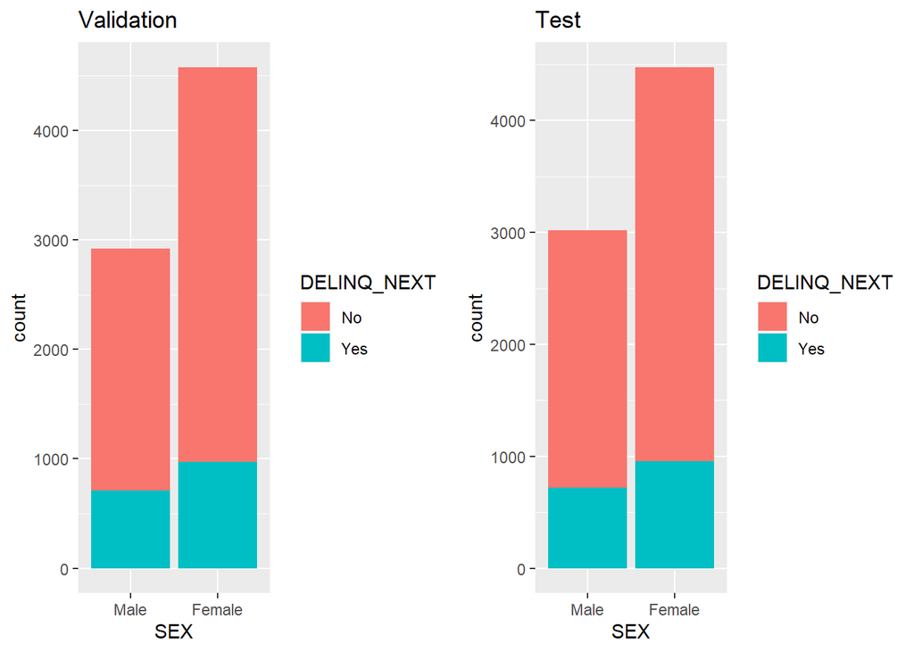

### Comparison of Race in Validation vs Test Data

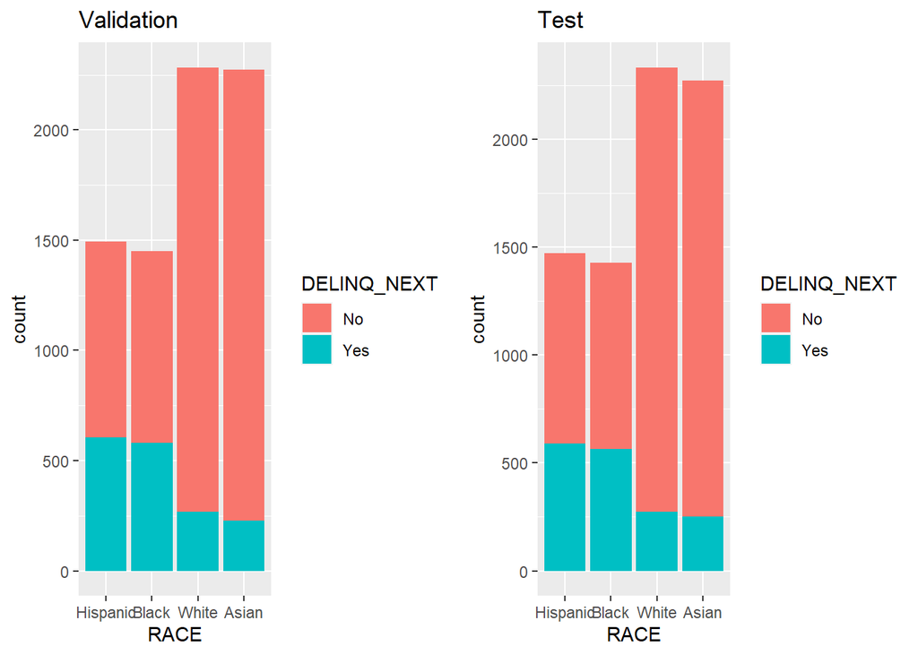